# Banking Data Analysis

## Association Rule Mining

This association rule mining task focuses on analyzing banking data, with each row in the dataset representing an individual person, and each column in the dataset representing attributes related to that person’s banking and demographic information. The goal of this task is to discover association rules within this dataset, particularly rules related to whether or not a particular person would want to obtain a PEP (Personal Equity Plan). To begin data preprocessing, the package libraries and banking dataset used in this problem are first loaded.

```r
library(ggplot2)
library(dplyr)
library(tidyr)
library(arules)
bank_data <- read.csv("bankdata.csv", TRUE, ",")
dim(bank_data)
```

```
## [1] 600  12
```

```r
str(bank_data)
```

```
## 'data.frame':    600 obs. of  12 variables:
##  $ id         : Factor w/ 600 levels "ID12101","ID12102",..: 1 2 3 4 5 6 7 8 9 10 ...
##  $ age        : int  48 40 51 23 57 57 22 58 37 54 ...
##  $ sex        : Factor w/ 2 levels "FEMALE","MALE": 1 2 1 1 1 1 2 2 1 2 ...
##  $ region     : Factor w/ 4 levels "INNER_CITY","RURAL",..: 1 4 1 4 2 4 2 4 3 4 ...
##  $ income     : num  17546 30085 16575 20375 50576 ...
##  $ married    : Factor w/ 2 levels "NO","YES": 1 2 2 2 2 2 1 2 2 2 ...
##  $ children   : int  1 3 0 3 0 2 0 0 2 2 ...
##  $ car        : Factor w/ 2 levels "NO","YES": 1 2 2 1 1 1 1 2 2 2 ...
##  $ save_act   : Factor w/ 2 levels "NO","YES": 1 1 2 1 2 2 1 2 1 2 ...
##  $ current_act: Factor w/ 2 levels "NO","YES": 1 2 2 2 1 2 2 2 1 2 ...
##  $ mortgage   : Factor w/ 2 levels "NO","YES": 1 2 1 1 1 1 1 1 1 1 ...
##  $ pep        : Factor w/ 2 levels "NO","YES": 2 1 1 1 1 2 2 1 1 1 ...
```

Preprocessing of the data is done by first removing the unnecessary attribute, ‘id’, from the dataset, as well as removing any ‘NA’ values that may be present in the dataset. All numeric attributes are then converted to the ‘factor’ class, as numerical attributes need to be discretized for association rule discovery. As a final preprocessing step, the dataset is converted from the ‘data frame’ class to the ‘transactions’ class (another requirement of association rule mining). Three dataset items (transactions) are displayed to help visualize the data.

```r
bank_data <- bank_data %>%
    select(-id) %>%
    drop_na()
bank_data$age <- factor(bank_data$age)
bank_data$income <- factor(bank_data$income)
bank_data$children <- factor(bank_data$children)

bank_data <- as(bank_data, "transactions")
class(bank_data)
```

```
## [1] "transactions"
## attr(,"package")
## [1] "arules"
```

```r
inspect(head(bank_data, 3))
```

```
##     items               transactionID
## [1] {age=48,
##      sex=FEMALE,
##      region=INNER_CITY,
##      income=17546,
##      married=NO,
##      children=1,
##      car=NO,
##      save_act=NO,
##      current_act=NO,
##      mortgage=NO,
##      pep=YES}                       1
## [2] {age=40,
##      sex=MALE,
##      region=TOWN,
##      income=30085.1,
##      married=YES,
##      children=3,
##      car=YES,
##      save_act=NO,
##      current_act=YES,
##      mortgage=YES,
##      pep=NO}                        2
## [3] {age=51,
##      sex=FEMALE,
##      region=INNER_CITY,
##      income=16575.4,
##      married=YES,
##      children=0,
##      car=YES,
##      save_act=YES,
##      current_act=YES,
##      mortgage=NO,
##      pep=NO}                        3
```

```r
bank_rules <- apriori(bank_data, parameter = list(support = 0.01,confidence = 0.5,minlen = 3))
```

```
## Apriori
##
## Parameter specification:
##  confidence minval smax arem  aval originalSupport maxtime support minlen
##         0.5    0.1    1 none FALSE            TRUE       5    0.01      3
##  maxlen target   ext
##      10  rules FALSE
##
## Algorithmic control:
##  filter tree heap memopt load sort verbose
##     0.1 TRUE TRUE  FALSE TRUE    2    TRUE
##
## Absolute minimum support count: 6
##
## set item appearances ...[0 item(s)] done [0.00s].
## set transactions ...[671 item(s), 600 transaction(s)] done [0.00s].
## sorting and recoding items ... [71 item(s)] done [0.00s].
## creating transaction tree ... done [0.00s].
## checking subsets of size 1 2 3 4 5 6 7 8 9 done [0.01s].
## writing ... [38287 rule(s)] done [0.01s].
## creating S4 object  ... done [0.02s].
```

```r
bank_rules <- apriori(bank_data, parameter = list(support = 0.05,confidence = 0.6,minlen = 3))
```

```
## Apriori
##
## Parameter specification:
##  confidence minval smax arem  aval originalSupport maxtime support minlen
##         0.6    0.1    1 none FALSE            TRUE       5    0.05      3
##  maxlen target   ext
##      10  rules FALSE
##
## Algorithmic control:
##  filter tree heap memopt load sort verbose
##     0.1 TRUE TRUE  FALSE TRUE    2    TRUE
##
## Absolute minimum support count: 30
##
## set item appearances ...[0 item(s)] done [0.00s].
## set transactions ...[671 item(s), 600 transaction(s)] done [0.00s].
## sorting and recoding items ... [22 item(s)] done [0.00s].
## creating transaction tree ... done [0.00s].
## checking subsets of size 1 2 3 4 5 6 7 done [0.00s].
## writing ... [3058 rule(s)] done [0.00s].
## creating S4 object  ... done [0.00s].
```

```r
bank_rules <- apriori(bank_data, parameter = list(support = 0.14,confidence = 0.70,minlen = 3,arem="diff"))
```

```
## Apriori
##
## Parameter specification:
##  confidence minval smax arem  aval originalSupport maxtime support minlen
##         0.7    0.1    1 diff FALSE            TRUE       5    0.14      3
##  maxlen target   ext
##      10  rules FALSE
##
## Algorithmic control:
##  filter tree heap memopt load sort verbose
##     0.1 TRUE TRUE  FALSE TRUE    2    TRUE
##
## Absolute minimum support count: 84
##
## set item appearances ...[0 item(s)] done [0.00s].
## set transactions ...[671 item(s), 600 transaction(s)] done [0.00s].
## sorting and recoding items ... [20 item(s)] done [0.00s].
## creating transaction tree ... done [0.00s].
## checking subsets of size 1 2 3 4 5 done [0.00s].
## writing ... [22 rule(s)] done [0.00s].
## creating S4 object  ... done [0.00s].
```

```r
inspect(head(sort(bank_rules, by = "lift", decreasing = T), 10))
```

```
##      lhs                  rhs             support confidence     lift count
## [1]  {married=YES,
##       children=0,
##       save_act=YES}    => {pep=NO}      0.1783333  0.8991597 1.654895   107
## [2]  {married=YES,
##       children=0,
##       mortgage=NO}     => {pep=NO}      0.1733333  0.8965517 1.650095   104
## [3]  {married=NO,
##       mortgage=NO}     => {pep=YES}     0.1533333  0.7076923 1.549691    92
## [4]  {children=0,
##       mortgage=NO,
##       pep=NO}          => {married=YES} 0.1733333  0.9719626 1.472671   104
## [5]  {married=YES,
##       children=0,
##       current_act=YES} => {pep=NO}      0.1750000  0.7894737 1.453019   105
## [6]  {married=YES,
##       children=0}      => {pep=NO}      0.2350000  0.7833333 1.441718   141
## [7]  {children=0,
##       save_act=YES,
##       current_act=YES} => {pep=NO}      0.1683333  0.7593985 1.397666   101
## [8]  {children=0,
##       save_act=YES}    => {pep=NO}      0.2183333  0.7528736 1.385657   131
## [9]  {save_act=YES,
##       mortgage=NO,
##       pep=NO}          => {married=YES} 0.2000000  0.8450704 1.280410   120
## [10] {children=0,
##       pep=NO}          => {married=YES} 0.2350000  0.8443114 1.279260   141
```

In order to see which strong rules have a strong correlation to the ‘pep’ attribute, indicating which combinations of attributes result in customers wanting or not wanting PEP, the right hand side (RHS) of the rules are set to be equal to only either ‘pep=YES’ or ‘pep=NO’. After narrowing the strong rules down to those with their RHS equal to the PEP attribute, only 7 strong rules were discovered.

```r
bank_rules <- apriori(bank_data, parameter = list(support = 0.14,confidence = 0.70,minlen = 3,arem="diff"), appearance = list(default = "lhs", rhs = c("pep=YES", "pep=NO")))
```

```
## Apriori
##
## Parameter specification:
##  confidence minval smax arem  aval originalSupport maxtime support minlen
##         0.7    0.1    1 diff FALSE            TRUE       5    0.14      3
##  maxlen target   ext
##      10  rules FALSE
##
## Algorithmic control:
##  filter tree heap memopt load sort verbose
##     0.1 TRUE TRUE  FALSE TRUE    2    TRUE
##
## Absolute minimum support count: 84
##
## set item appearances ...[2 item(s)] done [0.00s].
## set transactions ...[671 item(s), 600 transaction(s)] done [0.00s].
## sorting and recoding items ... [20 item(s)] done [0.00s].
## creating transaction tree ... done [0.00s].
## checking subsets of size 1 2 3 4 5 done [0.00s].
## writing ... [7 rule(s)] done [0.00s].
## creating S4 object  ... done [0.00s].
```

```r
inspect(head(sort(bank_rules, by = "lift", decreasing = T), 10))
```

```
##     lhs                  rhs         support confidence     lift count
## [1] {married=YES,
##      children=0,
##      save_act=YES}    => {pep=NO}  0.1783333  0.8991597 1.654895   107
## [2] {married=YES,
##      children=0,
##      mortgage=NO}     => {pep=NO}  0.1733333  0.8965517 1.650095   104
## [3] {married=NO,
##      mortgage=NO}     => {pep=YES} 0.1533333  0.7076923 1.549691    92
## [4] {married=YES,
##      children=0,
##      current_act=YES} => {pep=NO}  0.1750000  0.7894737 1.453019   105
## [5] {married=YES,
##      children=0}      => {pep=NO}  0.2350000  0.7833333 1.441718   141
## [6] {children=0,
##      save_act=YES,
##      current_act=YES} => {pep=NO}  0.1683333  0.7593985 1.397666   101
## [7] {children=0,
##      save_act=YES}    => {pep=NO}  0.2183333  0.7528736 1.385657   131
```

1: {married=YES, children=0, save_act=YES} => {pep=NO}; support=0.178; confidence=0.899; lift=1.655

2: {married=YES, children=0, mortgage=NO} => {pep=NO}; support=0.173; confidence=0.896; lift=1.650

4: {children=0, save_act=YES, current_act=YES} => {pep=NO}; support=0.168; confidence=0.759; lift=1.398

5: {married=NO, mortgage=NO} => {pep=YES}; support=0.153; confidence=0.708; lift=1.550

## Cluster Analysis

This cluster analysis task focuses on investigating the authorship of the Federalist papers, with 11/85 of these papers having a disputed authorship of either Alexander Hamilton or James Madison. Each row in the dataset used for this problem represents the one paper, with the author of each paper being either “Hamilton”, “Madison”, “Jay”, “HM” (Hamilton and Madison), or “dispt” (disputed authorship), and the feature values (percentage of each word occurence in the paper) being the remaining attributes of the dataset. The goal of this task is to use the k-Means and HAC clustering algorithms to provide evidence to draw conclusions on whether or not Hamilton or Madison wrote each disputed paper. To begin data preprocessing, the package libraries and banking dataset used in this problem are first loaded.

```r
library("factoextra")
essay_data <- read.csv("Disputed_Essay_data.csv", TRUE, ",")
dim(essay_data)
```

```
## [1] 85 72
```

```r
str(essay_data)
```

```
## 'data.frame':    85 obs. of  72 variables:
##  $ author  : Factor w/ 5 levels "dispt","Hamilton",..: 1 1 1 1 1 1 1 1 1 1 ...
##  $ filename: Factor w/ 85 levels "dispt_fed_49.txt",..: 1 2 3 4 5 6 7 8 9 10 ...
##  $ a       : num  0.28 0.177 0.339 0.27 0.303 0.245 0.349 0.414 0.248 0.442 ...
##  $ all     : num  0.052 0.063 0.09 0.024 0.054 0.059 0.036 0.083 0.04 0.062 ...
##  $ also    : num  0.009 0.013 0.008 0.016 0.027 0.007 0.007 0.009 0.007 0.006 ...
##  $ an      : num  0.096 0.038 0.03 0.024 0.034 0.067 0.029 0.018 0.04 0.075 ...
##  $ and     : num  0.358 0.393 0.301 0.262 0.404 0.282 0.335 0.478 0.356 0.423 ...
##  $ any     : num  0.026 0.063 0.008 0.056 0.04 0.052 0.058 0.046 0.034 0.037 ...
##  $ are     : num  0.131 0.051 0.068 0.064 0.128 0.111 0.087 0.11 0.154 0.093 ...
##  $ as      : num  0.122 0.139 0.203 0.111 0.148 0.252 0.073 0.074 0.161 0.1 ...
##  $ at      : num  0.017 0.114 0.023 0.056 0.013 0.015 0.116 0.037 0.047 0.031 ...
##  $ be      : num  0.411 0.393 0.474 0.365 0.344 0.297 0.378 0.331 0.289 0.379 ...
##  $ been    : num  0.026 0.165 0.015 0.127 0.047 0.03 0.044 0.046 0.027 0.025 ...
##  $ but     : num  0.009 0 0.038 0.032 0.061 0.037 0.007 0.055 0.027 0.037 ...
```

[output cut: 58 more lines]

Preprocessing of the data is done by first removing the unnecessary attribute, ‘filename’, from the dataset. The ‘author’ column of the dataset is needed to be converted to be the row names for the dataframe. Since the row names for the dataset are required to be unique values in order to be processed, the author column is passed as a paramter into the function ‘make.names()’, along with the parameter ‘unique=TRUE’. These new row names are combined with the remaining columns of class ‘num’ via the function ‘data.frame()’. The row names are displayed to verify that the new row names are unique in value, and are in the format “dispt”, “dispt.1”, “dispt.2”, “dispt.3”, “dispt.4”, etc. for each author. Any ‘NA’ values potentially present in the dataset are then removed, and the final step of preprocessing uses the function ‘scale’ to scale and center the dataset. The ‘head()’ function is used on the dataset before and after scaling and centering in order to display the new values.

```r
essay_data <- essay_data[,!(names(essay_data) %in% c("filename"))]
essay_data <- data.frame(essay_data[,-1], row.names = make.names(essay_data[,1], unique = TRUE))
row.names(essay_data)
```

```
##  [1] "dispt"       "dispt.1"     "dispt.2"     "dispt.3"     "dispt.4"
##  [6] "dispt.5"     "dispt.6"     "dispt.7"     "dispt.8"     "dispt.9"
## [11] "dispt.10"    "Hamilton"    "Hamilton.1"  "Hamilton.2"  "Hamilton.3"
## [16] "Hamilton.4"  "Hamilton.5"  "Hamilton.6"  "Hamilton.7"  "Hamilton.8"
## [21] "Hamilton.9"  "Hamilton.10" "Hamilton.11" "Hamilton.12" "Hamilton.13"
## [26] "Hamilton.14" "Hamilton.15" "Hamilton.16" "Hamilton.17" "Hamilton.18"
## [31] "Hamilton.19" "Hamilton.20" "Hamilton.21" "Hamilton.22" "Hamilton.23"
## [36] "Hamilton.24" "Hamilton.25" "Hamilton.26" "Hamilton.27" "Hamilton.28"
## [41] "Hamilton.29" "Hamilton.30" "Hamilton.31" "Hamilton.32" "Hamilton.33"
## [46] "Hamilton.34" "Hamilton.35" "Hamilton.36" "Hamilton.37" "Hamilton.38"
## [51] "Hamilton.39" "Hamilton.40" "Hamilton.41" "Hamilton.42" "Hamilton.43"
## [56] "Hamilton.44" "Hamilton.45" "Hamilton.46" "Hamilton.47" "Hamilton.48"
## [61] "Hamilton.49" "Hamilton.50" "HM"          "HM.1"        "HM.2"
## [66] "Jay"         "Jay.1"       "Jay.2"       "Jay.3"       "Jay.4"
## [71] "Madison"     "Madison.1"   "Madison.2"   "Madison.3"   "Madison.4"
## [76] "Madison.5"   "Madison.6"   "Madison.7"   "Madison.8"   "Madison.9"
## [81] "Madison.10"  "Madison.11"  "Madison.12"  "Madison.13"  "Madison.14"
```

```r
essay_data <- na.omit(essay_data)
head(essay_data)
```

```
##             a   all  also    an   and   any   are    as    at    be  been
## dispt   0.280 0.052 0.009 0.096 0.358 0.026 0.131 0.122 0.017 0.411 0.026
## dispt.1 0.177 0.063 0.013 0.038 0.393 0.063 0.051 0.139 0.114 0.393 0.165
## dispt.2 0.339 0.090 0.008 0.030 0.301 0.008 0.068 0.203 0.023 0.474 0.015
## dispt.3 0.270 0.024 0.016 0.024 0.262 0.056 0.064 0.111 0.056 0.365 0.127
## dispt.4 0.303 0.054 0.027 0.034 0.404 0.040 0.128 0.148 0.013 0.344 0.047
## dispt.5 0.245 0.059 0.007 0.067 0.282 0.052 0.111 0.252 0.015 0.297 0.030
##           but    by   can    do  down  even every  for.  from   had   has
## dispt   0.009 0.140 0.035 0.026 0.000 0.009 0.044 0.096 0.044 0.035 0.017
## dispt.1 0.000 0.139 0.000 0.013 0.000 0.025 0.000 0.076 0.101 0.101 0.013
## dispt.2 0.038 0.173 0.023 0.000 0.008 0.015 0.023 0.098 0.053 0.008 0.015
## dispt.3 0.032 0.167 0.056 0.000 0.000 0.024 0.040 0.103 0.079 0.016 0.024
## dispt.4 0.061 0.209 0.088 0.000 0.000 0.020 0.027 0.141 0.074 0.000 0.054
## dispt.5 0.037 0.186 0.000 0.000 0.007 0.007 0.007 0.067 0.096 0.022 0.015
##          have her   his   if.   in.  into    is    it   its   may  more
## dispt   0.044   0 0.017 0.000 0.262 0.009 0.157 0.175 0.070 0.035 0.026
## dispt.1 0.152   0 0.000 0.025 0.291 0.025 0.038 0.127 0.038 0.038 0.000
## dispt.2 0.023   0 0.000 0.023 0.308 0.038 0.150 0.173 0.030 0.120 0.038
## dispt.3 0.143   0 0.024 0.040 0.238 0.008 0.151 0.222 0.048 0.056 0.056
## dispt.4 0.047   0 0.020 0.034 0.263 0.013 0.189 0.108 0.013 0.047 0.067
## dispt.5 0.119   0 0.067 0.030 0.401 0.037 0.260 0.156 0.015 0.074 0.045
##          must my    no   not now    of    on   one  only    or   our shall
## dispt   0.026  0 0.035 0.114   0 0.900 0.140 0.026 0.035 0.096 0.017 0.017
## dispt.1 0.013  0 0.000 0.127   0 0.747 0.139 0.025 0.000 0.114 0.000 0.000
## dispt.2 0.083  0 0.030 0.068   0 0.858 0.150 0.030 0.023 0.060 0.000 0.008
## dispt.3 0.071  0 0.032 0.087   0 0.802 0.143 0.032 0.048 0.064 0.016 0.016
## dispt.4 0.013  0 0.047 0.128   0 0.869 0.054 0.047 0.027 0.081 0.027 0.000
## dispt.5 0.015  0 0.059 0.134   0 0.876 0.141 0.052 0.022 0.074 0.030 0.015
##         should    so  some  such  than  that   the their  then there
## dispt    0.017 0.035 0.009 0.026 0.009 0.184 1.425 0.114 0.000 0.009
## dispt.1  0.013 0.013 0.063 0.000 0.000 0.152 1.254 0.165 0.000 0.000
## dispt.2  0.068 0.038 0.030 0.045 0.023 0.188 1.490 0.053 0.015 0.015
## dispt.3  0.032 0.040 0.024 0.008 0.000 0.238 1.326 0.071 0.008 0.000
## dispt.4  0.000 0.027 0.067 0.027 0.047 0.162 1.193 0.027 0.007 0.007
## dispt.5  0.030 0.007 0.045 0.015 0.030 0.208 1.469 0.089 0.007 0.007
##         things  this    to up  upon   was  were  what  when which   who
## dispt    0.009 0.044 0.507  0 0.000 0.009 0.017 0.000 0.009 0.175 0.044
## dispt.1  0.000 0.051 0.355  0 0.013 0.051 0.000 0.000 0.000 0.114 0.038
## dispt.2  0.000 0.075 0.361  0 0.000 0.008 0.015 0.008 0.000 0.105 0.008
## dispt.3  0.000 0.103 0.532  0 0.000 0.087 0.079 0.008 0.024 0.167 0.000
## dispt.4  0.000 0.094 0.485  0 0.000 0.027 0.020 0.020 0.007 0.155 0.027
## dispt.5  0.000 0.126 0.445  0 0.000 0.007 0.030 0.015 0.037 0.186 0.045
##          will  with would your
## dispt   0.009 0.087 0.192    0
## dispt.1 0.089 0.063 0.139    0
## dispt.2 0.173 0.045 0.068    0
## dispt.3 0.079 0.079 0.064    0
## dispt.4 0.168 0.074 0.040    0
## dispt.5 0.111 0.089 0.037    0
```

```r
essay_data <- scale(essay_data, center = T, scale = T)
head(essay_data)
```

```
##                  a         all        also          an         and
## dispt   -0.1723368 -0.03534435  0.15950160  0.93187600 -0.23253417
## dispt.1 -1.5135000  0.43010589  0.63520811 -1.02557977  0.07316143
## dispt.2  0.5959023  1.57257465  0.04057497 -1.29557367 -0.73038129
## dispt.3 -0.3025468 -1.22012677  0.99198800 -1.49806910 -1.07101353
## dispt.4  0.1271463  0.04928297  2.30018092 -1.16057672  0.16923719
## dispt.5 -0.6280719  0.26085126 -0.07835166 -0.04685188 -0.89633033
##                 any        are          as         at          be
## dispt   -0.68518464  1.5654231 -0.05418106 -1.0404489  1.26866739
## dispt.1  0.93870812 -0.7567578  0.36449075  2.6603712  1.06077823
## dispt.2 -1.47518652 -0.2632943  1.94066694 -0.8115322  1.99627946
## dispt.3  0.63148517 -0.3794034 -0.32508634  0.4475097  0.73739509
## dispt.4 -0.07073873  1.4783413  0.58614052 -1.1930600  0.49485773
## dispt.5  0.45592919  0.9848779  3.14742684 -1.1167544 -0.04796397
##               been        but        by         can         do       down
## dispt   -1.0162916 -1.3159303 0.2605755 -0.02062228  3.0053860 -0.4239542
## dispt.1  3.1791960 -1.8238448 0.2402926 -1.27268916  1.0262730 -0.4239542
## dispt.2 -1.3483086  0.3206833 0.9299109 -0.44990235 -0.9528399  1.7936523
## dispt.3  2.0322282 -0.0179264 0.8082135  0.73061785 -0.9528399 -0.4239542
## dispt.4 -0.3824410  1.6186872 1.6600949  1.87536471 -0.9528399 -0.4239542
## dispt.5 -0.8955582  0.2642484 1.1935884 -1.27268916 -0.9528399  1.5164515
##               even       every        for.        from         had
## dispt   -0.2431406  1.09472692  0.06360606 -1.31170510  0.61463684
## dispt.1  1.3777967 -1.30239174 -0.50550078  0.77813746  3.54670543
## dispt.2  0.3647109 -0.04935244  0.12051674 -0.98172996 -0.58484577
## dispt.3  1.2764881  0.87680704  0.26279345 -0.02846844 -0.22944351
## dispt.4  0.8712538  0.16856744  1.34409646 -0.21178797 -0.94024802
## dispt.5 -0.4457577 -0.92103196 -0.76159886  0.59481793  0.03710818
##                has       have        her        his        if.        in.
## dispt   -1.1001862 -1.3396177 -0.3769551 -0.2733913 -1.5128966 -0.7758578
## dispt.1 -1.2606596  1.5116901 -0.3769551 -0.6732398 -0.1289512 -0.3693776
## dispt.2 -1.1804229 -1.8940386 -0.3769551 -0.6732398 -0.2396668 -0.1310961
## dispt.3 -0.8193579  1.2740811 -0.3769551 -0.1087477  0.7014161 -1.1122552
## dispt.4  0.3841920 -1.2604147 -0.3769551 -0.2028298  0.3692692 -0.7618412
## dispt.5 -1.1804229  0.6404571 -0.3769551  0.9026339  0.1478379  1.1724439
##               into          is         it         its        may
## dispt   -0.7853726  0.01246845  0.4072769  0.72662889 -0.8830840
## dispt.1  0.0471346 -2.02169914 -0.6633995 -0.34810226 -0.7842747
## dispt.2  0.7235467 -0.10718847  0.3626654 -0.61678505  1.9165132
## dispt.3 -0.8374043 -0.09009462  1.4556476 -0.01224877 -0.1914188
```

[output cut: 36 more lines]

```
## dispt.5  0.1509958 -0.8787198 -0.6067331  1.3432342 -0.87106363 -0.5120406
##               upon         was        were       what       when
## dispt   -1.0657505 -0.57950415 -0.15447029 -1.1025238 -0.2068178
## dispt.1 -0.5916546  0.86621899 -0.96910375 -1.1025238 -0.8858546
## dispt.2 -1.0657505 -0.61392613 -0.25030952 -0.4165986 -0.8858546
## dispt.3 -1.0657505  2.10541024  2.81654586 -0.4165986  0.9249103
## dispt.4 -1.0657505  0.04009148 -0.01071144  0.6122890 -0.3577148
## dispt.5 -1.0657505 -0.64834810  0.46848471  0.1835858  1.9057413
##              which        who       will       with      would       your
## dispt    0.4006641  0.4609835 -1.3597325  0.2849510  1.2098029 -0.2087646
## dispt.1 -1.0164186  0.2198537 -0.1463229 -0.6496151  0.4995915 -0.2087646
## dispt.2 -1.2254963 -0.9857954  1.1277571 -1.3505396 -0.4518237 -0.2087646
## dispt.3  0.2148172 -1.3073018 -0.2979991 -0.0265710 -0.5054246 -0.2087646
## dispt.4 -0.0639532 -0.2222177  1.0519190 -0.2212723 -0.8270297 -0.2087646
## dispt.5  0.6562036  0.5011718  0.1873647  0.3628315 -0.8672304 -0.2087646
```

Before performing the ‘kmeans()’ function on the dataset, the seed is first set to an arbitrary value so that the same results are achieved whenever this code is run. After the seed is set, the ‘kmeans()’ function is run on the dataset, along with parameters indicating that 4 clusters (centroids) should be produced in the output (parameter ‘centers’), 25 random sets should be selected (paramter ‘nstart’), at most 100 interations are permitted (parameter ‘iter.max’), and that the algorithm “Hartigan-Wong” should be used (parameter ‘algorithm’). The results of the k-Means clustering algorithm are displayed in two different formats, ‘str(kmeans_output)’ and ‘kmeans_output’. The former format of the results displays several values of the components associated with the returned ‘kmeans’ object, including the components ‘cluster’, ‘centers’, ‘totss’, ‘withinss’, ‘betweenss’, etc. The latter format of the results displays the mean values associated with each cluster and word attribute, the cluster in which each Federalist paper is grouped in, the sum of squares per cluster, and the components available mentioned previously.

```r
set.seed(1234)
kmeans_output <- kmeans(essay_data, centers = 4, nstart = 25, iter.max = 100, algorithm = "Hartigan-Wong")
str(kmeans_output)
```

```
## List of 9
##  $ cluster     : Named int [1:85] 3 1 3 3 3 3 3 3 3 3 ...
##   ..- attr(*, "names")= chr [1:85] "dispt" "dispt.1" "dispt.2" "dispt.3" ...
##  $ centers     : num [1:4, 1:70] -0.576 0.2896 -0.0627 -1.3703 0.1762 ...
##   ..- attr(*, "dimnames")=List of 2
##   .. ..$ : chr [1:4] "1" "2" "3" "4"
##   .. ..$ : chr [1:70] "a" "all" "also" "an" ...
##  $ totss       : num 5880
##  $ withinss    : num [1:4] 636 2768 1181 335
##  $ tot.withinss: num 4920
##  $ betweenss   : num 960
##  $ size        : int [1:4] 11 46 24 4
##  $ iter        : int 4
##  $ ifault      : int 0
##  - attr(*, "class")= chr "kmeans"
```

```r
kmeans_output
```

```
## K-means clustering with 4 clusters of sizes 11, 46, 24, 4
##
## Cluster means:
##             a          all        also         an        and         any
## 1 -0.57598787  0.176223940 -0.07835166 -0.3045733  0.7401337 -0.88866997
## 2  0.28962572 -0.008668348 -0.33688781  0.4564520 -0.4292426  0.31853756
## 3 -0.06274336  0.038704552  0.41717596 -0.5024666  0.1495853 -0.21337796
## 4 -1.37026902 -0.617157145  1.58662115 -1.3968214  2.0034108  0.06092825
##          are         as         at         be        been         but
## 1 -0.2474613 -0.3541919  0.5272837 -1.3393966  0.27336121 -0.64897176
## 2 -0.1269924 -0.1157504  0.1638521  0.1704703  0.07424644 -0.04491703
## 3  0.4019137  0.3655169 -0.3934412  0.2648322 -0.05293925  0.29481729
## 4 -0.2705511  0.1120563 -0.9736815  0.1339390 -1.28794190  0.53231438
##           by         can          do       down        even      every
## 1  0.4744678 -0.88893879 -0.67604087 -0.4239542 -0.39970839 -0.6189158
## 2 -0.4488847  0.15202297  0.11283630  0.1846824  0.16870081 -0.1429159
## 3  0.6611626  0.07030163 -0.02037322 -0.0890032 -0.07851415  0.6725072
## 4 -0.1095873  0.27450777  0.68373426 -0.4239542 -0.36977631 -0.6894921
##          for.         from        had         has       have         her
## 1 -0.06056271  0.008195461  1.6808436  0.01947992  0.4388495  0.02101943
## 2  0.02154164  0.071958773 -0.2033678  0.16005265  0.0596352 -0.19775612
## 3  0.06123478 -0.286643438 -0.2738688 -0.16743504 -0.1427725 -0.00244272
## 4 -0.44859010  0.869797219 -0.6403774 -0.88956500 -1.0360062  2.23104823
##          his         if.        in.         into         is         it
## 1  0.2055717 -0.41580531 -0.5515928  0.392435886 -0.8577637 -0.7161222
## 2  0.1014028  0.09127669  0.4786243 -0.284284711  0.1789476  0.2045855
## 3 -0.2136100 -0.27657201 -0.4937745 -0.009233076  0.2396741 -0.1122614
## 4 -0.4497950  1.75321470 -1.0246517  2.245473953 -1.1370926  0.2901717
##          its         may       more        must          my          no
## 1 -0.3206233 -1.11663332 -0.1067859 -0.77537462 -0.02090334 -0.77992250
## 2  0.2352606  0.06920864 -0.2880071  0.09850013  0.15721793  0.06580667
## 3 -0.2473462  0.31909596  0.1948770  0.25975274 -0.22413956  0.32764604
## 4 -0.3397059  0.36026651  2.4364815 -0.55898773 -0.40568466 -0.57786607
##           not        now         of         on         one        only
## 1 -0.58955133  0.3780618 -0.2435579  0.2131969  0.09429220 -0.62459918
## 2 -0.04176153  0.1049530  0.3506382 -0.5643201 -0.31726578 -0.07651245
## 3  0.29793854 -0.2331719 -0.2382584  1.0056141  0.07239926  0.38610287
## 4  0.31389252 -0.8475975 -1.9330044 -0.1302955  2.95485737  0.28092370
##            or         our      shall     should          so       some
## 1 -0.38365788 -0.26303984 -0.3792315 -0.2724530 -0.08521280  0.6392920
```

[output cut: 50 more lines]

```
##           3           3           3           1           3           3
##   Madison.8   Madison.9  Madison.10  Madison.11  Madison.12  Madison.13
##           3           3           3           3           3           1
##  Madison.14
##           3
##
## Within cluster sum of squares by cluster:
## [1]  635.8673 2767.8903 1180.9695  334.9720
##  (between_SS / total_SS =  16.3 %)
##
## Available components:
##
## [1] "cluster"      "centers"      "totss"        "withinss"
## [5] "tot.withinss" "betweenss"    "size"         "iter"
## [9] "ifault"
```

The ‘fviz_cluster()’ method is then performed on the ‘kmeans’ object returned from the ‘kmeans()’ function in order to visualize the output in a multidimensional graph, in which the number of clusters indicated as a parameter in the ‘kmeans()’ function (4 clusters in this case) are displayed in differing colors. All 85 papers are displayed in this graph, with each paper being displayed in the cluster/centroid in which it was found to be the most closely associated with by the ‘kmeans()’ function. The ‘fviz_cluster()’ function takes as arguments the returned kmeans object, a palette indicating the colors for the four clusters, the theme and title of the graph, as well as the size of the font for the text written on the graph.

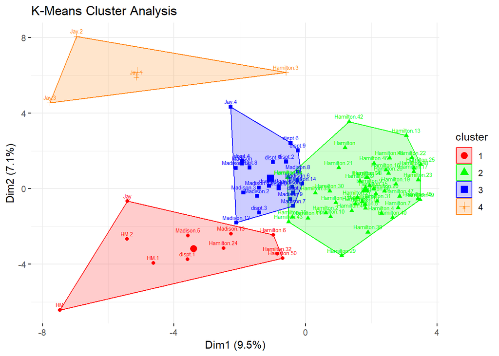

```r
fviz_cluster(kmeans_output, data = essay_data,
             palette = c("#FF0000","#00FF00","#0000FF","#FF7F00"),
             ggtheme = theme_minimal(),
             main = "K-Means Cluster Analysis",
             labelsize = 6)
```

It’s apparent to see in the plot returned by the ‘fviz_cluster()’ method that there are four distinct clusters/centroids in which the 85 Federalist papers were grouped, with two of these clusters having a slight overlap between them. The orange cluster primarily contains the papers written by Jay, the red cluster primarily contains the papers written by both Hamilton and Madison together, along with a few papers from either Hamilton or Madison, the blue cluster primary contains the papers written by Madison, and the green cluster primarily contains the papers written by Hamilton. There are 11 papers in the red (‘HM’ and mixed) cluster, 46 in the green (“Hamilton”) cluster, 24 in the blue (“Madison”) cluster, and 4 in the orange (“Jay”) cluster, which is proportional to the number of papers actually written per author. Based on the evidence provided by the centroids in this plot, conclusions can be drawn on whether or not Hamilton or Madison wrote each disputed paper. Out of the 11 disputed papers, 8 of these papers are unquestionably in the blue cluster, which primarily contains the papers written by Madison; therefore, it is likely that these 8 disputed papers are also written by Madison. 2/11 of the disputed papers are in a cross section between the blue (Madison) and green (Hamilton) clusters, so the conclusion of whether or not Hamilton or Madison wrote those 2 papers is less certain. Based on the fact that these two papers are located in the far left area of the green cluster, and farther away from the green centroid center than they are from the blue centroid center, it is more likely that these two papers were written by Madison, rather than Hamilton. The 11th paper is located in the red cluster, which contains the three papers written by both Hamilton and Madison, as well as a few papers written by either Hamilton or Madison; therefore, the author of this paper is also more difficult to conclude. Due to the fact that this paper is also closer to the center of the blue centroid than the center of the green centroid, it can be presumed that this paper was also written by Madison. The most useful attribute of these centroids for clustering analysis and drawing conclusions seems to be the location of the center of each centroid, as the centroid center values on these dimensions are far enough apart from each other to easily distinguish these clusters from one another and draw reasonable conclusions on who wrote the disputed essays.

A cluster analysis is then done on the same dataset using the HAC (Hierarchical Clustering) algorithm. As all necessary preprocessing has already been done on the datset for the k-Means algorithm, the dataset is passed into the ‘hclust()’ function via the ‘dist()’ function. In this ‘dist()’ function, the Euclidean distance function is specified as the method to be used. In addition to the ‘dist()’ function being passed as a parameter to the ‘hclust()’ method, a parameter indicating that the ‘complete’ agglomeration method should be used is also passed. The output from the ‘hclust()’ method is then plotted, along with the font size, hang, and title specified in the ‘plot()’ function. It’s clear to see in the plot displayed for the HAC output that there are distinct groupings (clusters) of each of the authors. Most of Jay’s papers are grouped to the far left of the plot, Hamilton’s papers are grouped continuously after Jay’s, followed by Madison’s papers, and finally the papers written by both Hamilton and Madison. Out of the 11 papers with disputed authorship, it appears that 8/11 of these papers are clearly mixed with papers written by Madison, so a conclusion can be drawn that these 8 papers were in fact written by Madison. The 3 remaining disputed papers seem to be mixed with papers written by Hamilton, although their placement in Hamilton’s cluster is close to the right hand side, particularly close to Madison’s cluster. Based on the visual evidence displayed in this HAC plot, it is reasonable to conclude that these 3 papers were more likely written by Hamilton, rather than Madison.

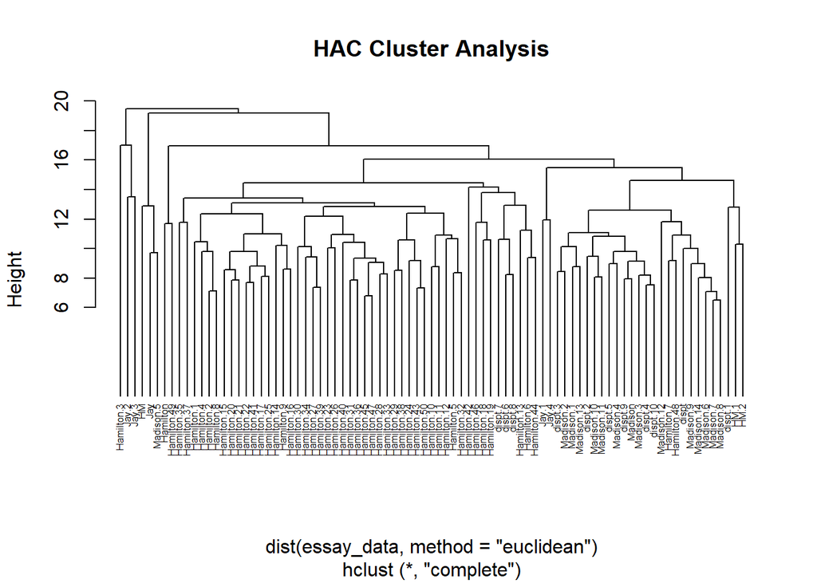

```r
hac_output <- hclust(dist(essay_data, method = "euclidean"), method = "complete")
plot(hac_output,cex = 0.5, hang = -1, main = "HAC Cluster Analysis")
```